# Clustering

Yanelli Nunez

8/13/2018

## Data Import and Cleaning

```r
#Need two periods to knit: "../"
#Need one period to run in console: "./"
#Or change file path to match your computer
studypop <- read_csv("../Data/studypop.csv") %>%
  clean_names() %>%
  na.omit() %>%
  mutate(bmi_cat3 = as.factor(bmi_cat3),
  edu_cat = as.factor(edu_cat),
  race_cat = as.factor(race_cat),
  male = as.factor(male))
#check dimensions of dataset
dim(studypop)
```

```
## [1] 1003   33
```

```r
#summary statistics on dataset
summary(studypop)
```

```
##       seqn          telomean         lbx074la         lbx099la
##  Min.   : 9966   Min.   :0.5266   Min.   :  1100   Min.   :  2000
##  1st Qu.:12720   1st Qu.:0.8758   1st Qu.:  4100   1st Qu.:  3700
##  Median :15452   Median :1.0310   Median :  7400   Median :  6300
##  Mean   :15524   Mean   :1.0533   Mean   : 12625   Mean   : 10005
##  3rd Qu.:18272   3rd Qu.:1.2037   3rd Qu.: 15600   3rd Qu.: 11700
##  Max.   :20993   Max.   :2.3512   Max.   :144000   Max.   :123000
##     lbx118la         lbx138la         lbx153la         lbx170la
##  Min.   :  2000   Min.   :  2100   Min.   :  2100   Min.   :  2000
##  1st Qu.:  4500   1st Qu.: 11700   1st Qu.: 16100   1st Qu.:  4900
##  Median :  9500   Median : 25700   Median : 36200   Median : 11400
##  Mean   : 16695   Mean   : 38092   Mean   : 52190   Mean   : 15505
##  3rd Qu.: 19500   3rd Qu.: 50000   3rd Qu.: 68400   3rd Qu.: 21700
##  Max.   :319000   Max.   :487000   Max.   :708000   Max.   :165000
##     lbx180la         lbx187la         lbxwbcsi         lbxlypct
##  Min.   :  2000   Min.   :  1100   Min.   : 2.300   Min.   : 5.80
##  1st Qu.: 10200   1st Qu.:  4000   1st Qu.: 5.700   1st Qu.:24.00
##  Median : 27400   Median :  8000   Median : 6.900   Median :29.00
##  Mean   : 37857   Mean   : 12116   Mean   : 7.216   Mean   :29.97
##  3rd Qu.: 53450   3rd Qu.: 16100   3rd Qu.: 8.350   3rd Qu.:35.45
##  Max.   :572000   Max.   :144000   Max.   :20.100   Max.   :73.40
##     lbxmopct         lbxnepct        lbxeopct         lbxbapct
##  Min.   : 1.600   Min.   :21.20   Min.   : 0.000   Min.   :0.0000
##  1st Qu.: 6.600   1st Qu.:52.15   1st Qu.: 1.500   1st Qu.:0.4000
##  Median : 7.800   Median :59.10   Median : 2.300   Median :0.6000
##  Mean   : 7.966   Mean   :58.59   Mean   : 2.867   Mean   :0.6511
##  3rd Qu.: 9.100   3rd Qu.:65.25   3rd Qu.: 3.700   3rd Qu.:0.8000
##  Max.   :23.800   Max.   :88.10   Max.   :28.200   Max.   :5.5000
##     lbxd03la         lbxd05la         lbxd07la         lbxf03la
##  Min.   :  1.40   Min.   :  1.90   Min.   :  36.8   Min.   : 0.700
##  1st Qu.: 21.40   1st Qu.: 23.95   1st Qu.: 196.9   1st Qu.: 2.300
##  Median : 38.00   Median : 41.70   Median : 346.0   Median : 5.200
##  Mean   : 48.06   Mean   : 57.44   Mean   : 494.1   Mean   : 6.697
##  3rd Qu.: 62.95   3rd Qu.: 72.35   3rd Qu.: 600.0   3rd Qu.: 9.250
##  Max.   :314.00   Max.   :760.00   Max.   :8190.0   Max.   :38.300
##     lbxf04la         lbxf05la         lbxf08la         lbxpcbla
##  Min.   : 1.000   Min.   : 0.800   Min.   :  0.90   Min.   :  1.3
##  1st Qu.: 3.200   1st Qu.: 2.600   1st Qu.:  6.40   1st Qu.: 14.9
##  Median : 5.300   Median : 4.300   Median :  9.80   Median : 24.8
##  Mean   : 6.432   Mean   : 5.433   Mean   : 11.57   Mean   : 38.6
##  3rd Qu.: 7.900   3rd Qu.: 6.900   3rd Qu.: 14.10   3rd Qu.: 43.5
##  Max.   :44.400   Max.   :33.500   Max.   :234.00   Max.   :845.0
##     lbxhxcla         lbx194la      bmi_cat3 edu_cat race_cat male
##  Min.   :  1.70   Min.   :  1100   1:316    1:318   1: 78    0:559
##  1st Qu.:  9.35   1st Qu.:  3700   2:373    2:228   2:227    1:444
##  Median : 18.50   Median :  6900   3:314    3:269   3:180
##  Mean   : 24.53   Mean   : 10450            4:188   4:518
##  3rd Qu.: 34.65   3rd Qu.: 14350
##  Max.   :172.00   Max.   :187000
##    ln_lbxcot          age_cent           age_sq
##  Min.   :-4.5099   Min.   :-23.000   Min.   :   0.0
##  1st Qu.:-4.0745   1st Qu.: -9.000   1st Qu.:  49.0
##  Median :-2.7031   Median :  2.000   Median : 196.0
##  Mean   :-0.9777   Mean   :  5.294   Mean   : 366.3
##  3rd Qu.: 2.5373   3rd Qu.: 20.000   3rd Qu.: 484.0
##  Max.   : 6.8189   Max.   : 42.000   Max.   :1764.0
```

```r
#extract POP variables from the studypop data frame
my.x <- names(studypop)[grep("la", names(studypop))]

#create a new data frame with my.x and convert values for the predictor variables to its natural log.
log.x <- data.frame(apply(studypop[,my.x], 2, FUN = function(x) log(x))) %>%
  setNames(paste(my.x, "l2", sep = ".")) %>% #add suffix 12 to the predictors' name
  na.omit() #remove missing

#check dimensions of dataset
dim(log.x)
```

```
## [1] 1003   18
```

```r
#summary statistics on dataset
summary(log.x)
```

```
##   lbx074la.l2      lbx099la.l2      lbx118la.l2      lbx138la.l2
##  Min.   : 7.003   Min.   : 7.601   Min.   : 7.601   Min.   : 7.650
##  1st Qu.: 8.319   1st Qu.: 8.216   1st Qu.: 8.412   1st Qu.: 9.367
##  Median : 8.909   Median : 8.748   Median : 9.159   Median :10.154
##  Mean   : 9.049   Mean   : 8.872   Mean   : 9.229   Mean   :10.092
##  3rd Qu.: 9.655   3rd Qu.: 9.367   3rd Qu.: 9.878   3rd Qu.:10.820
##  Max.   :11.878   Max.   :11.720   Max.   :12.673   Max.   :13.096
##   lbx153la.l2      lbx170la.l2      lbx180la.l2      lbx187la.l2
##  Min.   : 7.650   Min.   : 7.601   Min.   : 7.601   Min.   : 7.003
##  1st Qu.: 9.687   1st Qu.: 8.497   1st Qu.: 9.230   1st Qu.: 8.294
##  Median :10.497   Median : 9.341   Median :10.218   Median : 8.987
##  Mean   :10.408   Mean   : 9.285   Mean   :10.053   Mean   : 9.035
##  3rd Qu.:11.133   3rd Qu.: 9.985   3rd Qu.:10.887   3rd Qu.: 9.687
##  Max.   :13.470   Max.   :12.014   Max.   :13.257   Max.   :11.878
##   lbxd03la.l2      lbxd05la.l2      lbxd07la.l2     lbxf03la.l2
##  Min.   :0.3365   Min.   :0.6419   Min.   :3.605   Min.   :-0.3567
##  1st Qu.:3.0634   1st Qu.:3.1760   1st Qu.:5.283   1st Qu.: 0.8329
##  Median :3.6376   Median :3.7305   Median :5.846   Median : 1.6487
##  Mean   :3.5170   Mean   :3.7142   Mean   :5.881   Mean   : 1.5563
##  3rd Qu.:4.1423   3rd Qu.:4.2815   3rd Qu.:6.397   3rd Qu.: 2.2246
##  Max.   :5.7494   Max.   :6.6333   Max.   :9.011   Max.   : 3.6454
##   lbxf04la.l2     lbxf05la.l2       lbxf08la.l2       lbxpcbla.l2
##  Min.   :0.000   Min.   :-0.2231   Min.   :-0.1054   Min.   :0.2624
##  1st Qu.:1.163   1st Qu.: 0.9555   1st Qu.: 1.8563   1st Qu.:2.7014
##  Median :1.668   Median : 1.4586   Median : 2.2824   Median :3.2108
##  Mean   :1.643   Mean   : 1.4590   Mean   : 2.2114   Mean   :3.1866
##  3rd Qu.:2.067   3rd Qu.: 1.9315   3rd Qu.: 2.6462   3rd Qu.:3.7728
##  Max.   :3.793   Max.   : 3.5115   Max.   : 5.4553   Max.   :6.7393
##   lbxhxcla.l2      lbx194la.l2
##  Min.   :0.5306   Min.   : 7.003
##  1st Qu.:2.2354   1st Qu.: 8.216
##  Median :2.9178   Median : 8.839
##  Mean   :2.8476   Mean   : 8.924
##  3rd Qu.:3.5453   3rd Qu.: 9.571
##  Max.   :5.1475   Max.   :12.139
```

## Heat Map

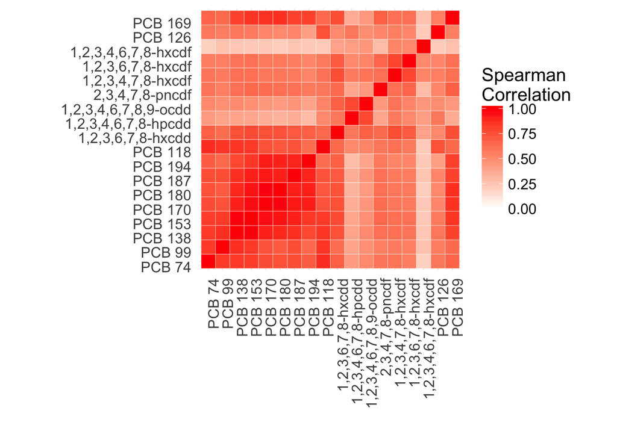

```r
cormat <- round(cor(studypop[grep("la", names(studypop))], use = "pairwise.complete.obs", method = c("spearman")),2)
melted_cormat <- melt(cormat) %>% rename(Correlation = value)

melted_cormat <- melted_cormat %>%
  mutate(group3.1 = case_when(Var1 == "lbx118la" ~ "TEQ",
                           grepl("lbxf|d", Var1) == TRUE ~ "TEQ",
                           grepl("lbx1|0", Var1) == TRUE ~ "Non-Dioxin-like PCB",
                           grepl("lbxh|p", Var1) == TRUE ~ "Non-Ortho PCB")) %>%
  mutate(group3.2 = case_when(Var2 == "lbx118la" ~ "TEQ",
                           grepl("lbxf|d", Var2) == TRUE ~ "TEQ",
                           grepl("lbx1|0", Var2) == TRUE ~ "Non-Dioxin-like PCB",
                           grepl("lbxh|p", Var2) == TRUE ~ "Non-Ortho PCB")) %>%
  mutate(Var1 = fct_recode(Var1, "PCB 74" = "lbx074la",
                                "PCB 99" = "lbx099la",
                                "PCB 118" = "lbx118la",
                                "PCB 138" = "lbx138la",
                                "PCB 153" = "lbx153la",
                                "PCB 170" = "lbx170la",
                                "PCB 180" = "lbx180la",
                                "PCB 187" = "lbx187la",
                                "PCB 194" = "lbx194la",
                                "1,2,3,6,7,8-hxcdd" = "lbxd03la",
                                "1,2,3,4,6,7,8-hpcdd" = "lbxd05la",
                               "1,2,3,4,6,7,8,9-ocdd" =  "lbxd07la",
                               "2,3,4,7,8-pncdf" =  "lbxf03la",
                               "1,2,3,4,7,8-hxcdf" =  "lbxf04la",
                               "1,2,3,6,7,8-hxcdf" =  "lbxf05la",
                               "1,2,3,4,6,7,8-hxcdf" =  "lbxf08la",
                               "PCB 169" =  "lbxhxcla",
                                "PCB 126" = "lbxpcbla"),
         Var2 = fct_recode(Var2, "PCB 74" = "lbx074la",
                                "PCB 99" = "lbx099la",
                                "PCB 118" = "lbx118la",
                                "PCB 138" = "lbx138la",
                                "PCB 153" = "lbx153la",
                                "PCB 170" = "lbx170la",
                                "PCB 180" = "lbx180la",
                                "PCB 187" = "lbx187la",
                                "PCB 194" = "lbx194la",
                                "1,2,3,6,7,8-hxcdd" = "lbxd03la",
                                "1,2,3,4,6,7,8-hpcdd" = "lbxd05la",
                               "1,2,3,4,6,7,8,9-ocdd" =  "lbxd07la",
                               "2,3,4,7,8-pncdf" =  "lbxf03la",
                               "1,2,3,4,7,8-hxcdf" =  "lbxf04la",
                               "1,2,3,6,7,8-hxcdf" =  "lbxf05la",
                               "1,2,3,4,6,7,8-hxcdf" =  "lbxf08la",
                               "PCB 169" =  "lbxhxcla",
                                "PCB 126" = "lbxpcbla"))

melted_cormat %>%
  mutate(Var1 = fct_relevel(Var1, "PCB 194", after = 8),
         Var2 = fct_relevel(Var2, "PCB 194", after = 8),
         Var1 = fct_relevel(Var1, "PCB 118", after = 8),
         Var2 = fct_relevel(Var2, "PCB 118", after = 8)) %>%
ggplot(aes(Var1, Var2, fill = Correlation)) +
 geom_tile(color = "white") +
 scale_fill_gradient2(low = "blue", high = "red", mid = "white",
                      midpoint = 0, limit = c(0,1), space = "Lab",
                      name = "Spearman\nCorrelation") +
  theme_minimal(base_size = 15) + # minimal theme
  theme(axis.text.x = element_text(angle = 90, vjust = 1, size = 12, hjust = 1),
        axis.text.y = element_text(vjust = 1, size = 12, hjust = 1),
        axis.title.x = element_text(size = 15),
        axis.title.y = element_text(size = 15)) +
  coord_fixed() + labs(x = "", y = "")
```

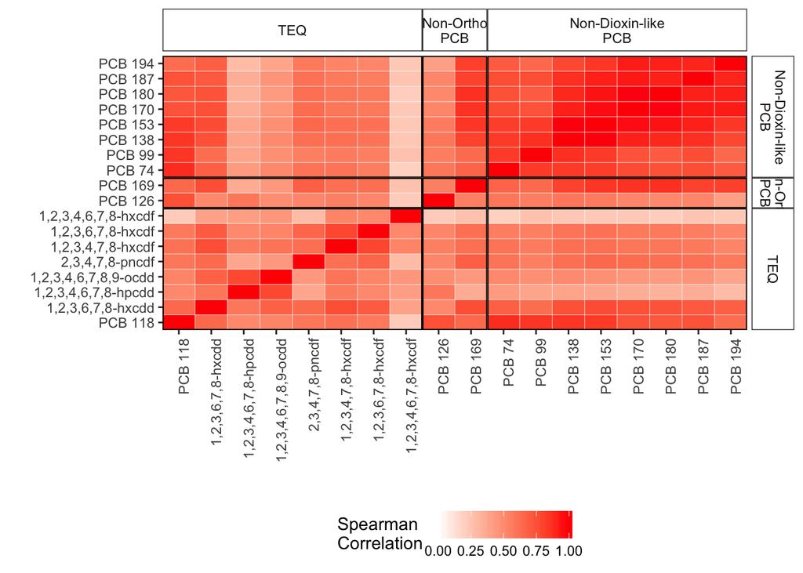

```r
melted_cormat %>%
 mutate(group3.1 = fct_relevel(group3.1, c("TEQ", "Non-Ortho PCB", "Non-Dioxin-like PCB"))) %>%
 ggplot(aes(Var1, Var2, fill = Correlation)) +
 geom_tile(color = "white") +
 scale_fill_gradient2(low = "blue", high = "red", mid = "white",
                      midpoint = 0, limit = c(0,1), space = "Lab",
                      name = "Spearman\nCorrelation ") +
  scale_x_discrete(expand = c(0, 0)) +
  scale_y_discrete(expand = c(0, 0)) + theme_bw() +
  theme(axis.text.x = element_text(angle = 90, hjust = 1),
        panel.spacing = unit(0, "lines"),
        panel.border = element_rect(colour = "black", size=0.7),
        strip.placement = "outside",
        legend.position = "bottom",
        strip.background = element_rect(fill = "white")) +
  labs(x = "", y = "") +
  facet_grid(group3.2 ~ group3.1, scales = "free", space = "free",
             labeller = labeller(group3.1 = label_wrap_gen(5),
                                 group3.2 = label_wrap_gen(5)))
```

## K-Means Clustering

```r
# for reproducibility, set seed
set.seed(28)


#K-menas with K = 1
km1 <- kmeans(log.x, 1, nstart = 20)

km1$size
```

```
## [1] 1003
```

```r
head(km1$centers) ## means
```

```
##   lbx074la.l2 lbx099la.l2 lbx118la.l2 lbx138la.l2 lbx153la.l2 lbx170la.l2
## 1    9.049383    8.872449    9.229251    10.09193    10.40847    9.284561
##   lbx180la.l2 lbx187la.l2 lbxd03la.l2 lbxd05la.l2 lbxd07la.l2 lbxf03la.l2
## 1    10.05278    9.035399    3.517011      3.7142    5.881141    1.556343
##   lbxf04la.l2 lbxf05la.l2 lbxf08la.l2 lbxpcbla.l2 lbxhxcla.l2 lbx194la.l2
## 1    1.642659    1.458998    2.211381    3.186607     2.84763    8.923956
```

```r
km1$totss ## total sum of squares
```

```
## [1] 13409.82
```

```r
km1$withinss ## within cluster sum of squares by cluster
```

```
## [1] 13409.82
```

```r
km1$tot.withinss ## total within cluster sum of squares -- this is what we want to minimize!
```

```
## [1] 13409.82
```

```r
km1$betweenss ## between cluster sum of squares
```

```
## [1] 0.0000000002146407
```

```r
Percent_bt_k1 = paste(round(100*(km1$betweenss/km1$totss),1), "%", sep = "")


#K-means with K = 2
km2 <- kmeans(log.x, 2, nstart = 20)

km2$size
```

```
## [1] 523 480
```

```r
head(km2$centers)
```

```
##   lbx074la.l2 lbx099la.l2 lbx118la.l2 lbx138la.l2 lbx153la.l2 lbx170la.l2
## 1    8.440417    8.352694    8.572514    9.355751    9.648429    8.618061
## 2    9.712902    9.438766    9.944820   10.894060   11.236596   10.010768
##   lbx180la.l2 lbx187la.l2 lbxd03la.l2 lbxd05la.l2 lbxd07la.l2 lbxf03la.l2
## 1    9.274152    8.402867    2.947864    3.369371    5.509764    1.059358
## 2   10.901150    9.724594    4.137145    4.089920    6.285788    2.097851
##   lbxf04la.l2 lbxf05la.l2 lbxf08la.l2 lbxpcbla.l2 lbxhxcla.l2 lbx194la.l2
## 1    1.264030    1.082943    2.050942    2.684926    2.236818    8.363294
## 2    2.055207    1.868741    2.386193    3.733230    3.513160    9.534843
```

```r
km2$totss
```

```
## [1] 13409.82
```

```r
km2$withinss
```

```
## [1] 3575.373 3583.479
```

```r
km2$tot.withinss
```

```
## [1] 7158.853
```

```r
km2$betweenss
```

```
## [1] 6250.97
```

```r
Percent_bt_k2 = paste(round(100*(km2$betweenss/km2$totss),1), "%", sep = "")

#K-means with K = 3
km3 <- kmeans(log.x, 3, nstart = 20)

km3$size
```

```
## [1] 248 396 359
```

```r
head(km3$centers)
```

```
##   lbx074la.l2 lbx099la.l2 lbx118la.l2 lbx138la.l2 lbx153la.l2 lbx170la.l2
## 1   10.104335    9.803940   10.383942   11.247201    11.57164   10.281591
## 2    9.072425    8.870616    9.250523   10.317655    10.67109    9.503245
## 3    8.295197    8.230990    8.408116    9.044872     9.31525    8.354583
##   lbx180la.l2 lbx187la.l2 lbxd03la.l2 lbxd05la.l2 lbxd07la.l2 lbxf03la.l2
## 1   11.184351   10.040340    4.425663    4.402407    6.568784    2.488071
## 2   10.385749    9.151089    3.688708    3.627991    5.854290    1.529040
## 3    8.903782    8.213564    2.699915    3.333877    5.435730    0.942816
##   lbxf04la.l2 lbxf05la.l2 lbxf08la.l2 lbxpcbla.l2 lbxhxcla.l2 lbx194la.l2
## 1    2.306138   2.1466477    2.541666    4.088041    3.787092    9.774738
## 2    1.649080   1.4527182    2.183954    3.136877    3.031001    9.049503
## 3    1.177238   0.9908904    2.013471    2.618746    1.996372    8.197742
```

```r
km3$totss
```

```
## [1] 13409.82
```

```r
km3$withinss
```

```
## [1] 1477.052 2322.222 1970.135
```

```r
km3$tot.withinss
```

```
## [1] 5769.409
```

```r
km3$betweenss
```

```
## [1] 7640.414
```

```r
Percent_bt_k3 = paste(round(100*(km3$betweenss/km3$totss),1), "%", sep = "")

#K-means with K = 5
km5 <- kmeans(log.x, 5, nstart = 20)

km5$size
```

```
## [1] 276 210 138 183 196
```

```r
head(km5$centers)
```

```
##   lbx074la.l2 lbx099la.l2 lbx118la.l2 lbx138la.l2 lbx153la.l2 lbx170la.l2
## 1    9.517383    9.240417    9.728501   10.700966   11.051671    9.867697
## 2    8.485602    8.401006    8.763901    9.486315    9.738876    8.540043
## 3   10.367255   10.093951   10.717982   11.501265   11.817980   10.472549
## 4    8.200314    8.140516    8.237196    8.729359    8.985962    8.200097
## 5    8.859277    8.682757    8.902880   10.163095   10.555903    9.437202
##   lbx180la.l2 lbx187la.l2 lbxd03la.l2 lbxd05la.l2 lbxd07la.l2 lbxf03la.l2
## 1   10.739825    9.544582    4.043774    4.042167    6.232492   1.9194971
## 2    9.277645    8.311601    3.288569    3.841659    5.876468   1.2079336
## 3   11.383839   10.295012    4.580476    4.555778    6.697486   2.7009428
## 4    8.586367    8.145434    2.276282    3.031267    5.152893   0.7689521
## 5   10.347762    9.037949    3.429673    3.160905    5.496560   1.3475344
##   lbxf04la.l2 lbxf05la.l2 lbxf08la.l2 lbxpcbla.l2 lbxhxcla.l2 lbx194la.l2
## 1   1.9371512   1.7396017    2.328949    3.597365    3.364475    9.411903
## 2   1.5066451   1.3206587    2.365180    3.051943    2.306057    8.219412
## 3   2.5025699   2.3228915    2.652463    4.357298    3.958381    9.933096
## 4   0.9530937   0.8059461    1.764190    2.395601    1.728371    8.135816
## 5   1.4120744   1.2135671    1.988014    2.666756    2.963046    9.017062
```

```r
km5$totss
```

```
## [1] 13409.82
```

```r
km5$withinss
```

```
## [1] 1407.0860  856.3865  699.9349  828.9872 1044.3112
```

```r
km5$tot.withinss
```

```
## [1] 4836.706
```

```r
km5$betweenss
```

```
## [1] 8573.117
```

```r
Percent_bt_k5 = paste(round(100*(km3$betweenss/km3$totss),1), "%", sep = "")

#K-means with K = 10
km10 <- kmeans(log.x, 10, nstart = 20)

km10$size
```

```
##  [1]  74 131 102  86 138 118  78 132  80  64
```

```r
head(km10$centers)
```

```
##   lbx074la.l2 lbx099la.l2 lbx118la.l2 lbx138la.l2 lbx153la.l2 lbx170la.l2
## 1   10.128008    9.969579   10.432661   11.439937   11.750811   10.438846
## 2    8.396366    8.290374    8.538663    9.314337    9.635063    8.442682
## 3    8.144253    8.109728    8.178372    8.605622    8.825137    8.128784
## 4   10.473668   10.140291   10.806363   11.539425   11.855482   10.503171
## 5    9.233201    9.007178    9.307293   10.600681   11.010956    9.941989
## 6    8.794002    8.657413    9.180549    9.969538   10.223974    8.945760
##   lbx180la.l2 lbx187la.l2 lbxd03la.l2 lbxd05la.l2 lbxd07la.l2 lbxf03la.l2
## 1   11.324352   10.187371    3.994491    3.749065    5.937019   2.2075132
## 2    9.183186    8.226992    2.995381    3.177810    5.310887   1.1002232
## 3    8.398901    8.112498    1.962109    2.904559    4.997250   0.6311062
## 4   11.410363   10.323777    4.811877    4.806101    6.947949   2.8562001
## 5   10.873621    9.591504    3.864413    3.468616    5.772795   1.6184643
## 6    9.782323    8.621780    3.696679    4.119183    6.170233   1.3823751
##   lbxf04la.l2 lbxf05la.l2 lbxf08la.l2 lbxpcbla.l2 lbxhxcla.l2 lbx194la.l2
## 1   1.8390047   1.7119282    2.166911    3.930159    3.799290    9.900632
## 2   1.2713794   1.0992772    1.968619    2.736384    2.169938    8.188897
## 3   0.8191693   0.6346889    1.592585    2.195303    1.544119    8.091847
## 4   2.6796942   2.5042471    2.741689    4.499214    4.051443    9.973570
## 5   1.7171400   1.5444385    2.214860    3.074309    3.375448    9.601897
## 6   1.7850504   1.6068401    2.517527    3.436213    2.637961    8.433680
```

```r
km10$totss
```

```
## [1] 13409.82
```

```r
km10$withinss
```

```
##  [1] 384.5570 405.8638 392.1536 302.9961 575.4865 405.9255 288.5845
##  [8] 533.2303 357.2993 317.6389
```

```r
km10$tot.withinss
```

```
## [1] 3963.736
```

```r
km10$betweenss
```

```
## [1] 9446.087
```

```r
Percent_bt_k10 = paste(round(100*(km10$betweenss/km10$totss),1), "%", sep = "")

#K-means with K = 100
km100 <- kmeans(log.x, 100, nstart = 20)

km100$size
```

```
##   [1]  4 13 14 26  2  9 15 13  9 10  8 11 21 18  2 15 11 17  3 16  7  8 19
##  [24]  3 20  5  7  2  9 11 11 24  3  7  9 18 14  9  6 14  9  4 10 11  4 12
##  [47]  8 10  2 13 19  7  4 13 25  9 14  8 17  5 13  4  9  7  7  5 14 11 11
##  [70]  4  8 16 15 15 11 10 11  7 12  9 16 10 12 10 10  4  6 11  3 17  4  1
##  [93]  1 13  1  5 12  3 11  7
```

```r
head(km100$centers)
```

```
##   lbx074la.l2 lbx099la.l2 lbx118la.l2 lbx138la.l2 lbx153la.l2 lbx170la.l2
## 1   10.406348   10.350190   10.091669   11.895922   12.221517   11.121779
## 2    7.965897    8.037200    8.267852    9.082593    9.417891    8.160318
## 3    9.862998    9.446331   10.148208   11.060787   11.425692   10.235858
## 4    9.220005    9.049533    9.461859   10.627592   11.029450    9.944650
## 5    7.962862    7.736869    8.008031    8.342840    8.377336    7.736869
## 6    9.492269    9.112723    9.453584   10.473334   10.840035    9.561110
##   lbx180la.l2 lbx187la.l2 lbxd03la.l2 lbxd05la.l2 lbxd07la.l2 lbxf03la.l2
## 1   12.131639   10.537575    4.688278    4.014085    6.359468    2.661622
## 2    8.902904    8.076531    2.665268    2.908531    4.977102    1.250669
## 3   11.145655   10.108323    4.416776    4.613585    6.619582    2.393268
## 4   10.849411    9.550492    3.828511    3.455915    5.669607    2.056937
## 5    8.712673    7.736869    3.178019    3.557434    6.289962    1.618947
## 6   10.443154    9.208128    4.232892    3.847777    5.952776    2.794803
##   lbxf04la.l2 lbxf05la.l2 lbxf08la.l2 lbxpcbla.l2 lbxhxcla.l2 lbx194la.l2
## 1    2.316717    2.146193    2.705054    2.437798    4.169530   10.670601
## 2    1.000147    1.009535    1.693195    2.881148    1.841385    7.939846
## 3    2.104438    2.153286    2.535774    3.989065    3.604988    9.843131
## 4    1.789916    1.604774    2.427967    3.389352    3.398245    9.533017
## 5    1.309427    1.189773    4.100309    2.612873    3.122801    8.180521
## 6    2.584124    2.507615    2.790354    3.675032    3.477277    8.982971
```

```r
km100$totss
```

```
## [1] 13409.82
```

```r
km100$withinss
```

```
##   [1]  7.866285 19.747114 20.000020 41.372509  3.512071 18.654303 24.575073
##   [8] 17.094739 14.995549 28.640855 22.595273 19.956361 37.138924 27.381020
##  [15]  3.708867 25.729189 25.429087 24.276536 18.783479 22.222011 16.974432
##  [22] 15.300094 23.340679  5.606289 34.529842  7.905223 11.157410  5.754252
##  [29] 27.051922 21.027050 19.993105 38.840731  7.799793 17.999515 15.981284
##  [36] 41.065634 21.187774 18.313460  8.234206 31.745383 23.021337  7.953437
##  [43] 15.878056 22.760510 15.248552 23.486326 18.446445 13.726989  3.673171
##  [50] 36.534135 29.054660 21.474778 13.155185 18.605835 37.566513 22.202102
##  [57] 22.918414 14.614507 31.802954 10.980339 16.336609 13.528545 19.499766
##  [64] 12.422824 14.670533 10.786499 28.528008 15.886590 15.750422  7.029274
##  [71] 16.789158 22.308075 30.955633 17.429438 26.130827 10.641106 16.913590
##  [78] 13.279405 26.137607 32.631164 32.031704 15.979504 20.955496 14.832833
##  [85] 16.812925  7.785153  9.873682 25.470321 10.256792 37.225428 12.064109
##  [92]  0.000000  0.000000 16.233094  0.000000  8.223982 17.280324  9.895730
##  [99] 20.304062 15.765522
```

```r
km100$tot.withinss
```

```
## [1] 1875.237
```

```r
km100$betweenss
```

```
## [1] 11534.59
```

```r
Percent_bt_k100 = paste(round(100*(km100$betweenss/km100$totss),1), "%", sep = "")
```

### Total Within Cluster/Total Variation

```r
# create an empty data frame
km.res <- data.frame(matrix(NA, (dim(log.x)[1] - 1), 3))
library(factoextra)
# use a loop to run k-means for 0 - 30 clusters and generate variance values
for (k in 1:(dim(log.x)[1] - 1)) {
  kk <- kmeans(log.x, k, nstart = 20)
  km.res[k, ] <- cbind(k, kk$tot.withinss, kk$totss)
  }
```

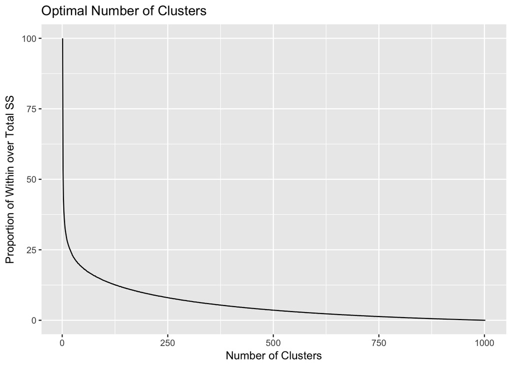

```r
# name the variables created
names(km.res) <- c("clusters", "WithinSS", "TotSS")

# create a variable for within cluster variance/total SS
km.res$PropWithin <- 100*km.res$WithinSS/km.res$TotSS

# compare the within cluster variance/total SS to number of clusters
km.res %>%
  ggplot(aes(x = clusters, y = PropWithin)) + geom_line() +
  labs(title = "Optimal Number of Clusters",
       y = "Proportion of Within over Total SS",
       x = "Number of Clusters")
```

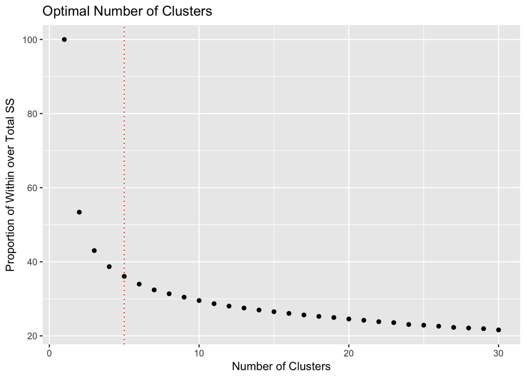

```r
# look at a smaller subset of data
km.res[1:30,]  %>%
  ggplot(aes(x = clusters, y = PropWithin)) + geom_point() +
  geom_vline(xintercept = 5, color = "red", linetype = "dotted") +
  labs(title = "Optimal Number of Clusters",
       y = "Proportion of Within over Total SS",
       x = "Number of Clusters")
```

### Summary Table

```r
summary.km <- matrix(c(km1$totss, km2$totss, km3$totss, km5$totss, km10$totss, km100$totss,
                       km1$tot.withinss, km2$tot.withinss, km3$tot.withinss, km5$tot.withinss, km10$tot.withinss, km100$tot.withinss,
                       km1$betweenss, km2$betweenss, km3$betweenss, km5$betweenss, km10$betweenss, km100$betweenss),
                     ncol = 3)
colnames(summary.km) <- c("Total SS", "Total within cluster SS", "Between cluster SS")
rownames(summary.km) <- c("km-1", "km-2", "km-3", "km-5", "km-10", "km-100")
summary.km <- round(as.table(summary.km), 2)
summary.km <- knitr::kable(summary.km)
summary.km
```

|  | Total SS | Total within cluster SS | Between cluster SS |
| --- | --- | --- | --- |
| km-1 | 13409.82 | 13409.82 | 0.00 |
| km-2 | 13409.82 | 7158.85 | 6250.97 |
| km-3 | 13409.82 | 5769.41 | 7640.41 |
| km-5 | 13409.82 | 4836.71 | 8573.12 |
| km-10 | 13409.82 | 3963.74 | 9446.09 |
| km-100 | 13409.82 | 1875.24 | 11534.59 |

k-means N = 3 using standardized data

```r
# for reproducibility, set seed
set.seed(29)

sd.log.x = scale(log.x)

summary(sd.log.x)
```

```
##   lbx074la.l2       lbx099la.l2       lbx118la.l2        lbx138la.l2
##  Min.   :-2.4013   Min.   :-1.6533   Min.   :-1.74475   Min.   :-2.47176
##  1st Qu.:-0.8574   1st Qu.:-0.8534   1st Qu.:-0.87585   1st Qu.:-0.73335
##  Median :-0.1645   Median :-0.1614   Median :-0.07522   Median : 0.06307
##  Mean   : 0.0000   Mean   : 0.0000   Mean   : 0.00000   Mean   : 0.00000
##  3rd Qu.: 0.7107   3rd Qu.: 0.6435   3rd Qu.: 0.69531   3rd Qu.: 0.73665
##  Max.   : 3.3189   Max.   : 3.7023   Max.   : 3.68987   Max.   : 3.04040
##   lbx153la.l2        lbx170la.l2        lbx180la.l2
##  Min.   :-2.73817   Min.   :-1.94046   Min.   :-2.3053
##  1st Qu.:-0.71652   1st Qu.:-0.90770   1st Qu.:-0.7735
##  Median : 0.08769   Median : 0.06547   Median : 0.1556
##  Mean   : 0.00000   Mean   : 0.00000   Mean   : 0.0000
##  3rd Qu.: 0.71925   3rd Qu.: 0.80735   3rd Qu.: 0.7839
##  Max.   : 3.03886   Max.   : 3.14540   Max.   : 3.0126
##   lbx187la.l2        lbxd03la.l2       lbxd05la.l2        lbxd07la.l2
##  Min.   :-2.44076   Min.   :-3.3904   Min.   :-3.67620   Min.   :-2.9446
##  1st Qu.:-0.89033   1st Qu.:-0.4836   1st Qu.:-0.64402   1st Qu.:-0.7740
##  Median :-0.05789   Median : 0.1285   Median : 0.01951   Median :-0.0449
##  Mean   : 0.00000   Mean   : 0.0000   Mean   : 0.00000   Mean   : 0.0000
##  3rd Qu.: 0.78204   3rd Qu.: 0.6666   3rd Qu.: 0.67882   3rd Qu.: 0.6674
##  Max.   : 3.41334   Max.   : 2.3797   Max.   : 3.49286   Max.   : 4.0495
##   lbxf03la.l2       lbxf04la.l2        lbxf05la.l2
##  Min.   :-2.2511   Min.   :-2.52793   Min.   :-2.4939048
##  1st Qu.:-0.8513   1st Qu.:-0.73793   1st Qu.:-0.7464574
##  Median : 0.1086   Median : 0.03855   Median :-0.0005673
##  Mean   : 0.0000   Mean   : 0.00000   Mean   : 0.0000000
##  3rd Qu.: 0.7863   3rd Qu.: 0.65282   3rd Qu.: 0.7005531
##  Max.   : 2.4583   Max.   : 3.30959   Max.   : 3.0430612
##   lbxf08la.l2       lbxpcbla.l2        lbxhxcla.l2        lbx194la.l2
##  Min.   :-3.3100   Min.   :-2.98816   Min.   :-2.61342   Min.   :-2.4456
##  1st Qu.:-0.5073   1st Qu.:-0.49585   1st Qu.:-0.69060   1st Qu.:-0.9012
##  Median : 0.1014   Median : 0.02477   Median : 0.07911   Median :-0.1078
##  Mean   : 0.0000   Mean   : 0.00000   Mean   : 0.00000   Mean   : 0.0000
##  3rd Qu.: 0.6212   3rd Qu.: 0.59896   3rd Qu.: 0.78691   3rd Qu.: 0.8244
##  Max.   : 4.6348   Max.   : 3.63038   Max.   : 2.59409   Max.   : 4.0931
```

```r
library(factoextra)
```

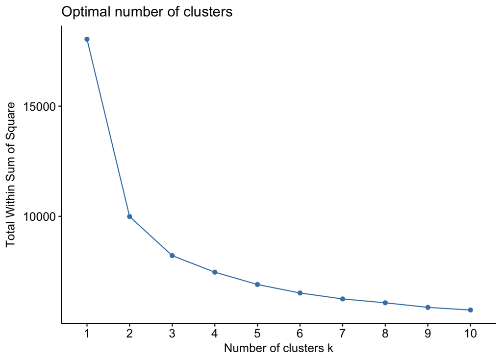

```r
fviz_nbclust(sd.log.x, kmeans, method = "wss") ###the loop below can quickly be perform using this function. Result is the same.
```

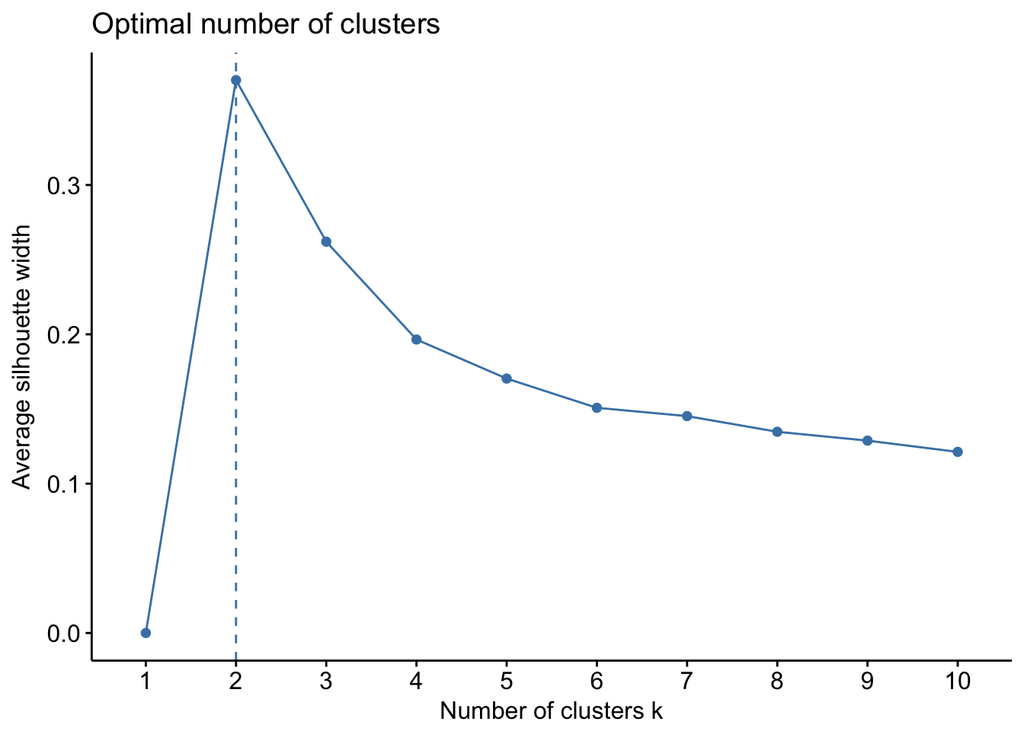

```r
fviz_nbclust(log.x, kmeans, method = "silhouette")
```

```r
#K-means with K = 3
sd_km3 <- kmeans(sd.log.x, 3, nstart = 20)
```

### Visualization

```r
##creating data frame with the chemical means within the population
chem_means <- as.data.frame(colMeans(log.x)) #chem means
chem_means$chem <- row.names(chem_means)

plot_chem_means <- chem_means %>%
  mutate(Group = ifelse(chem == "lbx118la.l2", "TEQ",
                        ifelse(grepl("lbx1", chem), "Non-Dioxin-like PCB",
                               ifelse(grepl("lbx0", chem), "Non-Dioxin-like PCB",
                                      ifelse(grepl("lbxp", chem), "Non-Ortho PCB",
                                             ifelse(grepl("lbxh", chem), "Non-Ortho PCB", "TEQ"))))))


##creating data fram with cluster means for k-means N=3
km3_centers <- as.data.frame.matrix(t(km3$centers)) #centers
km3_centers$chem <- row.names(km3_centers)

means_km3 <- km3_centers %>%
  mutate(Group = ifelse(chem == "lbx118la.l2", "TEQ",
                        ifelse(grepl("lbx1", chem), "Non-Dioxin-like PCB",
                               ifelse(grepl("lbx0", chem), "Non-Dioxin-like PCB",
                                      ifelse(grepl("lbxp", chem), "Non-Ortho PCB",
                                             ifelse(grepl("lbxh", chem), "Non-Ortho PCB", "TEQ"))))))
plot_means_km3 <- means_km3 %>%
  gather(key = "Cluster", value = "mean", -chem, -Group) %>% as.tibble()


##creating data frame with cluster means for k-means N=5
km5_centers <- as.data.frame.matrix(t(km5$centers))
km5_centers$chem <- row.names(km5_centers)

means_km5 <- km5_centers %>%
  mutate(Group = ifelse(chem == "lbx118la.l2", "TEQ",
                        ifelse(grepl("lbx1", chem), "Non-Dioxin-like PCB",
                               ifelse(grepl("lbx0", chem), "Non-Dioxin-like PCB",
                                      ifelse(grepl("lbxp", chem), "Non-Ortho PCB",
                                             ifelse(grepl("lbxh", chem), "Non-Ortho PCB", "TEQ"))))))
plot_means_km5 <- means_km5 %>%
  gather(key = "Cluster", value = "mean", -chem, -Group) %>% as.tibble()
```

Plots of cluster means for K-means N=3 and N=5

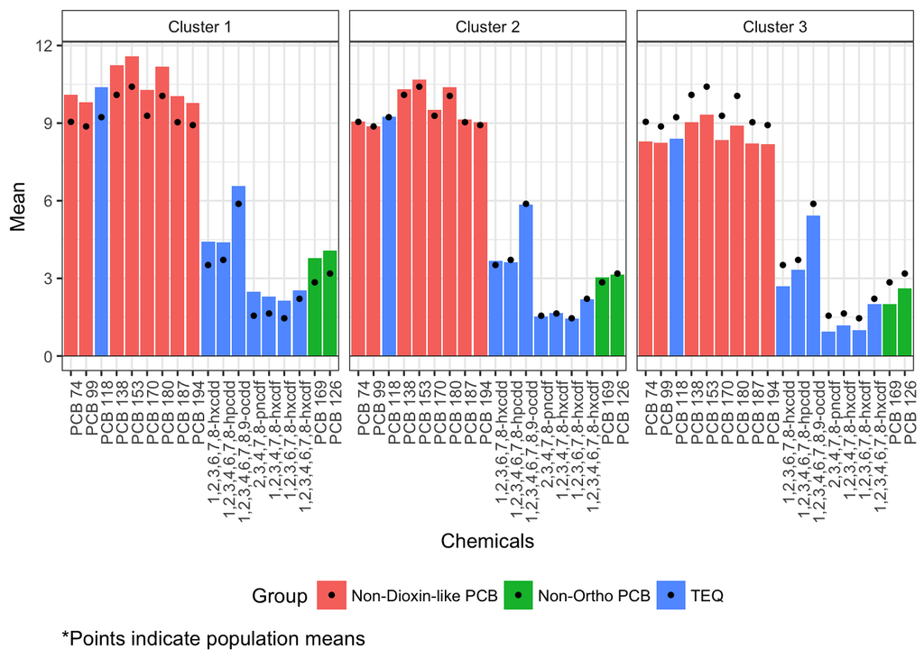

```r
 #K-means N=3
plot_chem_means %>% as.tibble() %>% rename(pop_mean = `colMeans(log.x)`) %>%
  right_join(., plot_means_km3, by = c("Group", "chem")) %>%
  mutate(Cluster = as.factor(Cluster),
         Cluster = fct_recode(Cluster, "Cluster 1" = "1",
         "Cluster 2" = "2",
         "Cluster 3" = "3")) %>%
  mutate(chem = fct_recode(chem, "PCB 74" = "lbx074la.l2",
                                "PCB 99" = "lbx099la.l2",
                                "PCB 118" = "lbx118la.l2",
                                "PCB 138" = "lbx138la.l2",
                                "PCB 153" = "lbx153la.l2",
                                "PCB 170" = "lbx170la.l2",
                                "PCB 180" = "lbx180la.l2",
                                "PCB 187" = "lbx187la.l2",
                                "PCB 194" = "lbx194la.l2",
                                "1,2,3,6,7,8-hxcdd" = "lbxd03la.l2",
                                "1,2,3,4,6,7,8-hpcdd" = "lbxd05la.l2",
                               "1,2,3,4,6,7,8,9-ocdd" =  "lbxd07la.l2",
                               "2,3,4,7,8-pncdf" =  "lbxf03la.l2",
                               "1,2,3,4,7,8-hxcdf" =  "lbxf04la.l2",
                               "1,2,3,6,7,8-hxcdf" =  "lbxf05la.l2",
                               "1,2,3,4,6,7,8-hxcdf" =  "lbxf08la.l2",
                               "PCB 169" =  "lbxhxcla.l2",
                                "PCB 126" = "lbxpcbla.l2")) %>%
  ggplot(aes(x = chem, y = mean, fill = Group)) + geom_col() +
  geom_point(aes(y = pop_mean), size = 1) +
  facet_wrap(~ Cluster) + theme_bw() +
  theme(legend.position = "bottom", axis.text.x = element_text(angle = 90, hjust = 1),
        plot.caption = element_text(size = 11, hjust = 0),
        strip.background = element_rect(fill = "white")) +
  geom_hline(yintercept = 0, size = 0.2) +
  labs(x = "Chemicals",
       y = "Mean", caption = "*Points indicate population means")
```

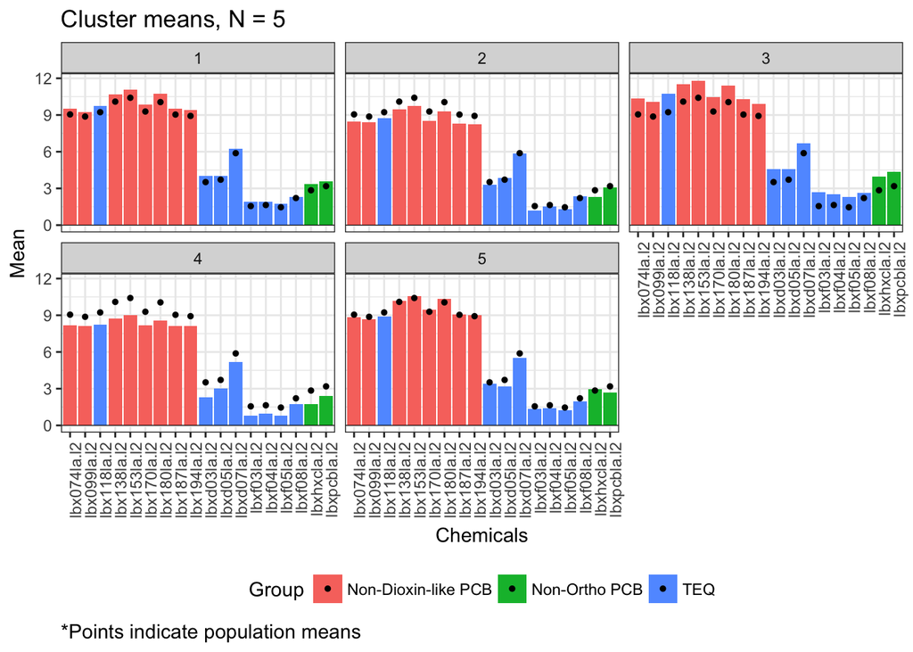

```r
#k-means N=5
plot_chem_means %>% as.tibble() %>% rename(pop_mean = `colMeans(log.x)`) %>%
  right_join(., plot_means_km5, by = c("Group", "chem")) %>%
  ggplot(aes(x = chem, y = mean, fill = Group)) + geom_col() +
  geom_point(aes(y = pop_mean), size = 1) +
  facet_wrap(~ Cluster) + theme_bw() +
  theme(legend.position = "bottom", axis.text.x = element_text(angle = 90, hjust = 1),
        plot.caption = element_text(size = 11, hjust = 0)) +
  geom_hline(yintercept = 0, size = 0.2) +
  labs(title = "Cluster means, N = 5", x = "Chemicals",
       y = "Mean", caption = "*Points indicate population means")
```

Plots of K-means N=3 with standardized data

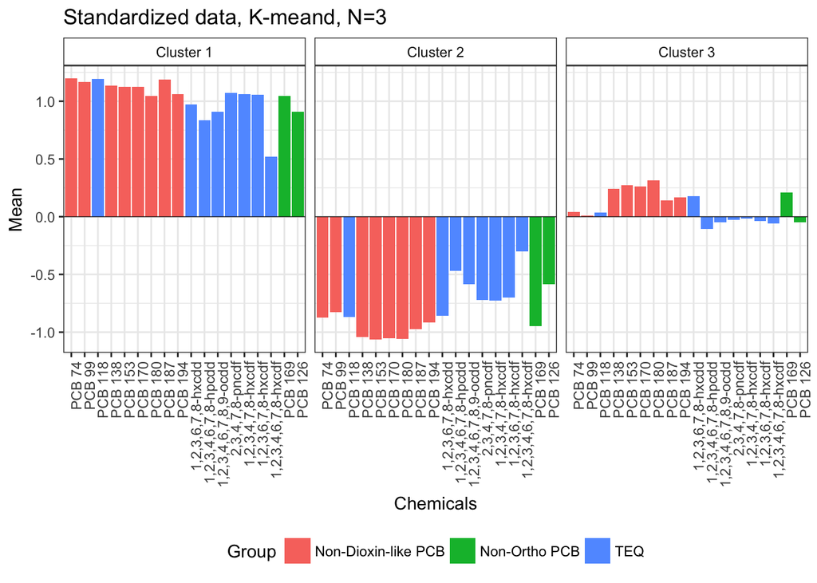

```r
##creating data fram with cluster means for k-means N=3 standarized
sd_km3_centers <- as.data.frame.matrix(t(sd_km3$centers)) #centers
sd_km3_centers$chem <- row.names(sd_km3_centers)

means_sd_km3 <- sd_km3_centers %>%
  mutate(Group = ifelse(chem == "lbx118la.l2", "TEQ",
                        ifelse(grepl("lbx1", chem), "Non-Dioxin-like PCB",
                               ifelse(grepl("lbx0", chem), "Non-Dioxin-like PCB",
                                      ifelse(grepl("lbxp", chem), "Non-Ortho PCB",
                                             ifelse(grepl("lbxh", chem), "Non-Ortho PCB", "TEQ"))))))
plot_means_sd_km3 <- means_sd_km3 %>%
  gather(key = "Cluster", value = "mean", -chem, -Group) %>% as.tibble()


plot_means_sd_km3 %>%
  mutate(Cluster = as.factor(Cluster),
         Cluster = fct_recode(Cluster, "Cluster 1" = "1",
         "Cluster 2" = "2",
         "Cluster 3" = "3")) %>%
  mutate(chem = fct_recode(chem, "PCB 74" = "lbx074la.l2",
                                "PCB 99" = "lbx099la.l2",
                                "PCB 118" = "lbx118la.l2",
                                "PCB 138" = "lbx138la.l2",
                                "PCB 153" = "lbx153la.l2",
                                "PCB 170" = "lbx170la.l2",
                                "PCB 180" = "lbx180la.l2",
                                "PCB 187" = "lbx187la.l2",
                                "PCB 194" = "lbx194la.l2",
                                "1,2,3,6,7,8-hxcdd" = "lbxd03la.l2",
                                "1,2,3,4,6,7,8-hpcdd" = "lbxd05la.l2",
                               "1,2,3,4,6,7,8,9-ocdd" =  "lbxd07la.l2",
                               "2,3,4,7,8-pncdf" =  "lbxf03la.l2",
                               "1,2,3,4,7,8-hxcdf" =  "lbxf04la.l2",
                               "1,2,3,6,7,8-hxcdf" =  "lbxf05la.l2",
                               "1,2,3,4,6,7,8-hxcdf" =  "lbxf08la.l2",
                               "PCB 169" =  "lbxhxcla.l2",
                                "PCB 126" = "lbxpcbla.l2")) %>%
  ggplot(aes(x = chem, y = mean, fill = Group)) + geom_col() +
  facet_wrap(~ Cluster) + theme_bw() +
  theme(legend.position = "bottom", axis.text.x = element_text(angle = 90, hjust = 1),
        plot.caption = element_text(size = 11, hjust = 0),
        strip.background = element_rect(fill = "white")) +
  geom_hline(yintercept = 0, size = 0.2) +
  labs(x = "Chemicals",
       y = "Mean",
       title = "Standardized data, K-meand, N=3")
```

### Health model

#### 5 Cluster Model

Combine clusters grouping with original data outcome and covariants for K-means = 5

```r
clu.group <- km5$cluster #cluster group

#Need two periods to knit: "../"
#Need one period to run in console: "./"
#Or change file path to match your computer
pop <- read_csv("../Data/studypop.csv") %>%
  clean_names() %>%
  na.omit() %>%
  select(-(3:10), -(17:26)) %>%
  mutate(logtelomean = log(telomean))
pop_clus <- as.tibble((cbind(pop, clu.group)))
table(pop_clus$clu.group)
```

```
##
##   1   2   3   4   5
## 276 210 138 183 196
```

Put 5 clusters (categorical) into a linear regression w/ covariates to estimate association with LTL.

```r
health_model_kmeans5 <- lm(logtelomean ~ as.factor(clu.group) +
     lbxwbcsi + lbxlypct + lbxmopct + lbxnepct + lbxeopct + lbxbapct + age_cent + age_sq +
as.factor(bmi_cat3) + as.factor(edu_cat) + as.factor(race_cat) + male, data = pop_clus)

health_model_kmeans5 %>% broom::tidy() %>% mutate(
  estimate = round(estimate, 4),
  std.error = round(std.error, 4),
  statistic = round(statistic, 4),
  p.value = round(p.value, 4))
```

```
## # A tibble: 22 x 5
##    term                  estimate std.error statistic p.value
##    <chr>                    <dbl>     <dbl>     <dbl>   <dbl>
##  1 (Intercept)            3.94      8.14        0.484  0.628
##  2 as.factor(clu.group)2 -0.0231    0.0229     -1.01   0.315
##  3 as.factor(clu.group)3  0.0429    0.0226      1.90   0.0577
##  4 as.factor(clu.group)4 -0.0704    0.0278     -2.53   0.0114
##  5 as.factor(clu.group)5 -0.0139    0.0202     -0.689  0.491
##  6 lbxwbcsi              -0.00500   0.00360    -1.40   0.161
##  7 lbxlypct              -0.0379    0.0813     -0.466  0.641
##  8 lbxmopct              -0.0431    0.0814     -0.530  0.596
##  9 lbxnepct              -0.0373    0.0813     -0.459  0.646
## 10 lbxeopct              -0.0368    0.0813     -0.453  0.651
## # ... with 12 more rows
```

```r
health_model_kmeans5 %>% broom::glance() %>% mutate(p.value = round(p.value, 5))
```

```
## # A tibble: 1 x 11
##   r.squared adj.r.squared sigma statistic p.value    df logLik   AIC   BIC
##       <dbl>         <dbl> <dbl>     <dbl>   <dbl> <int>  <dbl> <dbl> <dbl>
## 1     0.258         0.242 0.202      16.2      0.    22   193. -339. -226.
## # ... with 2 more variables: deviance <dbl>, df.residual <int>
```

```r
confint(health_model_kmeans5)
```

```
##                                 2.5 %         97.5 %
## (Intercept)           -12.02701856197 19.90141473671
## as.factor(clu.group)2  -0.06808029303  0.02195111936
## as.factor(clu.group)3  -0.00139779849  0.08720512599
## as.factor(clu.group)4  -0.12494086472 -0.01589756956
## as.factor(clu.group)5  -0.05363979553  0.02576445546
## lbxwbcsi               -0.01198492628  0.00198951287
## lbxlypct               -0.19747602319  0.12170514982
## lbxmopct               -0.20276674274  0.11652533107
## lbxnepct               -0.19688243747  0.12222112979
## lbxeopct               -0.19647386089  0.12278192589
## lbxbapct               -0.18083753754  0.14303233498
## age_cent               -0.00831359580 -0.00558125689
## age_sq                 -0.00004926015  0.00004129418
## as.factor(bmi_cat3)2   -0.03669336578  0.02616282841
## as.factor(bmi_cat3)3   -0.04974178861  0.01713413171
## as.factor(edu_cat)2    -0.01768427393  0.05478204277
## as.factor(edu_cat)3    -0.00366719798  0.06609837015
## as.factor(edu_cat)4    -0.03376348334  0.04744384749
## as.factor(race_cat)2   -0.08980782273  0.01658213068
## as.factor(race_cat)3   -0.06200038349  0.04953401258
## as.factor(race_cat)4   -0.09139284004  0.00732212878
## male                   -0.06119176751 -0.00772744145
```

##### Plot

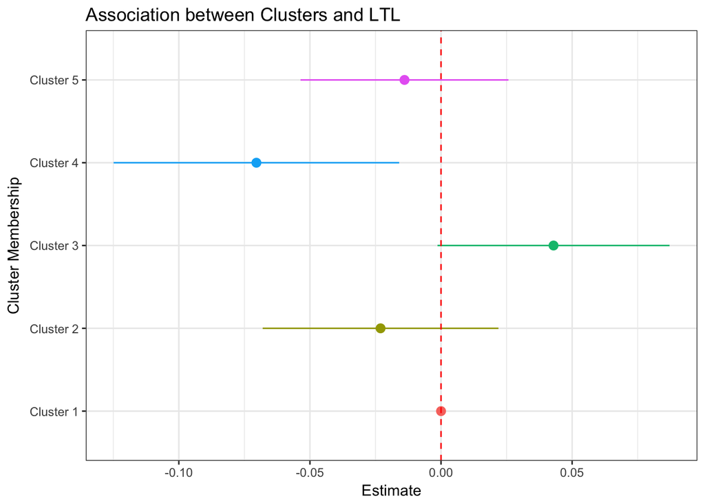

```r
health_model_kmeans5 %>% broom::tidy() %>% as.tibble() %>% filter(grepl("clu.group", term)) %>%
  mutate(term = ifelse(term == "as.factor(clu.group)2", "Cluster 2",
                  ifelse(term == "as.factor(clu.group)3", "Cluster 3",
                    ifelse(term == "as.factor(clu.group)4", "Cluster 4", "Cluster 5")))) %>%
      rbind(., c("Cluster 1", 0, 0, 0, 0)) %>%
  mutate(estimate = as.numeric(estimate),
         std.error = as.numeric(std.error)) %>%
  ggplot(aes(x = term, y = estimate, color = term,
             ymin = estimate - 1.96*std.error,
             ymax = estimate + 1.96*std.error)) +
  geom_pointrange() + theme_bw() +
  geom_hline(yintercept = 0, color = "red", linetype = "dashed") +
  theme(legend.position = "none") + coord_flip() +
  labs(y = "Estimate", x = "Cluster Membership", title = "Association between Clusters and LTL")
```

#### 3 Cluster Model

Combine clusters grouping with original data outcome and covariants for K-means = 3

```r
clu.group3 <- km3$cluster #cluster group

pop_clus3 <- as.tibble((cbind(pop, clu.group3))) %>%
  mutate(clu.group3 = as.factor(clu.group3)) %>%
  mutate(clu.group3 = fct_relevel(clu.group3, ref = "3"))
table(pop_clus3$clu.group3)
```

```
##
##   3   1   2
## 359 248 396
```

Put 3 clusters (categorical) into a linear regression w/ covariates to estimate association with LTL.

```r
health_model_kmeans3 <- lm(logtelomean ~ clu.group3 + age_cent + age_sq +
     lbxwbcsi + lbxlypct + lbxmopct + lbxnepct + lbxeopct + lbxbapct +
     as.factor(bmi_cat3) + as.factor(edu_cat) + as.factor(race_cat) + male, data = pop_clus3)

summary(health_model_kmeans3)
```

```
##
## Call:
## lm(formula = logtelomean ~ clu.group3 + age_cent + age_sq + lbxwbcsi +
##     lbxlypct + lbxmopct + lbxnepct + lbxeopct + lbxbapct + as.factor(bmi_cat3) +
##     as.factor(edu_cat) + as.factor(race_cat) + male, data = pop_clus3)
##
## Residuals:
##      Min       1Q   Median       3Q      Max
## -0.56608 -0.13177 -0.00503  0.12374  0.74454
##
## Coefficients:
##                          Estimate   Std. Error t value
## (Intercept)           3.228570986  8.126241120   0.397
## clu.group31           0.082435077  0.025128283   3.281
## clu.group32           0.053677515  0.019070023   2.815
## age_cent             -0.007061255  0.000658076 -10.730
## age_sq                0.000001469  0.000022350   0.066
## lbxwbcsi             -0.005390029  0.003548037  -1.519
## lbxlypct             -0.031326177  0.081240315  -0.386
## lbxmopct             -0.036810906  0.081264596  -0.453
## lbxnepct             -0.030835121  0.081220302  -0.380
## lbxeopct             -0.030527681  0.081261965  -0.376
## lbxbapct             -0.011680353  0.082414497  -0.142
## as.factor(bmi_cat3)2 -0.003931768  0.015941555  -0.247
## as.factor(bmi_cat3)3 -0.016126384  0.016823907  -0.959
## as.factor(edu_cat)2   0.018606782  0.018421920   1.010
## as.factor(edu_cat)3   0.031812990  0.017729340   1.794
## as.factor(edu_cat)4   0.010937199  0.020649595   0.530
## as.factor(race_cat)2 -0.033573501  0.027071453  -1.240
## as.factor(race_cat)3 -0.000485736  0.028216636  -0.017
## as.factor(race_cat)4 -0.040425995  0.025087251  -1.611
## male                 -0.035024326  0.013455176  -2.603
##                                  Pr(>|t|)
## (Intercept)                       0.69123
## clu.group31                       0.00107 **
## clu.group32                       0.00498 **
## age_cent             < 0.0000000000000002 ***
## age_sq                            0.94762
## lbxwbcsi                          0.12904
## lbxlypct                          0.69988
## lbxmopct                          0.65067
## lbxnepct                          0.70429
## lbxeopct                          0.70724
## lbxbapct                          0.88732
## as.factor(bmi_cat3)2              0.80524
## as.factor(bmi_cat3)3              0.33803
## as.factor(edu_cat)2               0.31273
## as.factor(edu_cat)3               0.07306 .
## as.factor(edu_cat)4               0.59647
## as.factor(race_cat)2              0.21520
## as.factor(race_cat)3              0.98627
## as.factor(race_cat)4              0.10741
## male                              0.00938 **
## ---
## Signif. codes:  0 '***' 0.001 '**' 0.01 '*' 0.05 '.' 0.1 ' ' 1
##
## Residual standard error: 0.2018 on 983 degrees of freedom
## Multiple R-squared:  0.2572, Adjusted R-squared:  0.2428
## F-statistic: 17.91 on 19 and 983 DF,  p-value: < 0.00000000000000022
```

```r
confint(health_model_kmeans3)
```

```
##                                2.5 %         97.5 %
## (Intercept)          -12.71820373381 19.17534570579
## clu.group31            0.03312383082  0.13174632265
## clu.group32            0.01625487947  0.09110015149
## age_cent              -0.00835265111 -0.00576985905
## age_sq                -0.00004239135  0.00004532867
## lbxwbcsi              -0.01235262626  0.00157256887
## lbxlypct              -0.19075056266  0.12809820826
## lbxmopct              -0.19628294127  0.12266112846
## lbxnepct              -0.19022023319  0.12854999160
## lbxeopct              -0.18999455356  0.12893919119
## lbxbapct              -0.17340893057  0.15004822450
## as.factor(bmi_cat3)2  -0.03521515980  0.02735162310
## as.factor(bmi_cat3)3  -0.04914128552  0.01688851700
## as.factor(edu_cat)2   -0.01754402963  0.05475759298
## as.factor(edu_cat)3   -0.00297871530  0.06660469456
## as.factor(edu_cat)4   -0.02958515837  0.05145955601
## as.factor(race_cat)2  -0.08669798452  0.01955098327
## as.factor(race_cat)3  -0.05585750350  0.05488603052
## as.factor(race_cat)4  -0.08965671992  0.00880472955
## male                  -0.06142849639 -0.00862015553
```

```r
health_model_kmeans3 %>% broom::tidy() %>% mutate(
  estimate = round(estimate, 4),
  std.error = round(std.error, 4),
  statistic = round(statistic, 4),
  p.value = round(p.value, 4))
```

```
## # A tibble: 20 x 5
##    term                  estimate std.error statistic p.value
##    <chr>                    <dbl>     <dbl>     <dbl>   <dbl>
##  1 (Intercept)           3.23      8.13        0.397  0.691
##  2 clu.group31           0.0824    0.0251      3.28   0.00110
##  3 clu.group32           0.0537    0.0191      2.81   0.00500
##  4 age_cent             -0.00710   0.000700  -10.7    0.
##  5 age_sq                0.        0.          0.0657 0.948
##  6 lbxwbcsi             -0.00540   0.00350    -1.52   0.129
##  7 lbxlypct             -0.0313    0.0812     -0.386  0.700
##  8 lbxmopct             -0.0368    0.0813     -0.453  0.651
##  9 lbxnepct             -0.0308    0.0812     -0.380  0.704
## 10 lbxeopct             -0.0305    0.0813     -0.376  0.707
## 11 lbxbapct             -0.0117    0.0824     -0.142  0.887
## 12 as.factor(bmi_cat3)2 -0.00390   0.0159     -0.247  0.805
## 13 as.factor(bmi_cat3)3 -0.0161    0.0168     -0.958  0.338
## 14 as.factor(edu_cat)2   0.0186    0.0184      1.01   0.313
## 15 as.factor(edu_cat)3   0.0318    0.0177      1.79   0.0731
## 16 as.factor(edu_cat)4   0.0109    0.0206      0.530  0.596
## 17 as.factor(race_cat)2 -0.0336    0.0271     -1.24   0.215
## 18 as.factor(race_cat)3 -0.000500  0.0282     -0.0172 0.986
## 19 as.factor(race_cat)4 -0.0404    0.0251     -1.61   0.107
## 20 male                 -0.0350    0.0135     -2.60   0.00940
```

```r
health_model_kmeans3 %>% broom::glance() %>% mutate(p.value = round(p.value, 5))
```

```
## # A tibble: 1 x 11
##   r.squared adj.r.squared sigma statistic p.value    df logLik   AIC   BIC
##       <dbl>         <dbl> <dbl>     <dbl>   <dbl> <int>  <dbl> <dbl> <dbl>
## 1     0.257         0.243 0.202      17.9      0.    20   192. -342. -239.
## # ... with 2 more variables: deviance <dbl>, df.residual <int>
```

```r
#summary table of the betas and confidence intervals for the cluster variables.

Kmeans3_betas_confint <- as.data.frame(c(health_model_kmeans3$coefficients["clu.group31"], health_model_kmeans3$coefficients["clu.group32"])) %>%
  rownames_to_column() %>%
  rename("variable" = 1) %>%
  rename("beta" = 2) %>%
  mutate('95%CI' = c("0.033, 0.132", "0.016, 0.091"),
       'P-value' = c((summary(health_model_kmeans3)$coefficients[2,4]),
                      summary(health_model_kmeans3)$coefficients[3,4]))

Kmeans3_betas_confint
```

```
##      variable       beta        95%CI     P-value
## 1 clu.group31 0.08243508 0.033, 0.132 0.001072392
## 2 clu.group32 0.05367752 0.016, 0.091 0.004978867
```

##### Plot

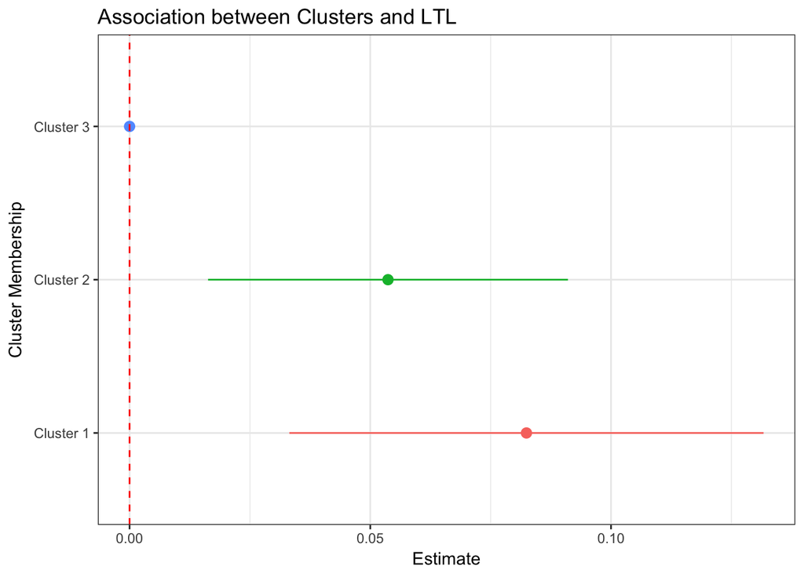

```r
health_model_kmeans3 %>% broom::tidy() %>% as.tibble() %>% filter(grepl("clu.group", term)) %>%
  mutate(term = ifelse(term == "clu.group32", "Cluster 2", "Cluster 1")) %>%
      rbind(., c("Cluster 3", 0, 0, 0, 0)) %>%
  mutate(estimate = as.numeric(estimate),
         std.error = as.numeric(std.error)) %>%
  ggplot(aes(x = term, y = estimate, color = term,
             ymin = estimate - 1.96*std.error,
             ymax = estimate + 1.96*std.error)) +
  geom_pointrange() + theme_bw() +
  geom_hline(yintercept = 0, color = "red", linetype = "dashed") +
  theme(legend.position = "none") + coord_flip() +
  labs(y = "Estimate", x = "Cluster Membership", title = "Association between Clusters and LTL")
```

## Hierarchical Clustering

```r
# Hierarchical clustering analysis
hc.complete <- hclust(dist(na.omit(log.x)), method = "complete")
hc.average  <- hclust(dist(na.omit(log.x)), method = "average")
hc.single   <- hclust(dist(na.omit(log.x)), method = "single")

#summary of outcome for each method
as.dendrogram(hc.complete) %>% head()
```

```
## --[dendrogram w/ 2 branches and 1003 members at h = 15.6]
##   |--[dendrogram w/ 2 branches and 494 members at h = 8.63]
##   |  |--[dendrogram w/ 2 branches and 118 members at h = 5.24]
##   |  |  |--[dendrogram w/ 2 branches and 84 members at h = 4.67] ..
##   |  |  `--[dendrogram w/ 2 branches and 34 members at h = 4.81] ..
##   |  `--[dendrogram w/ 2 branches and 376 members at h = 7.72]
##   |     |--[dendrogram w/ 2 branches and 282 members at h = 6.1] ..
##   |     `--[dendrogram w/ 2 branches and 94 members at h = 7.17] ..
##   `--[dendrogram w/ 2 branches and 509 members at h = 11.4]
##      |--[dendrogram w/ 2 branches and 320 members at h = 9.28]
##      |  |--[dendrogram w/ 2 branches and 4 members at h = 4.84] ..
##      |  `--[dendrogram w/ 2 branches and 316 members at h = 8.02] ..
##      `--[dendrogram w/ 2 branches and 189 members at h = 11.1]
##         |--leaf "1"
##         `--[dendrogram w/ 2 branches and 188 members at h = 8.05] ..
## etc...
```

```r
as.dendrogram(hc.average) %>% head()
```

```
## --[dendrogram w/ 2 branches and 1003 members at h = 10.1]
##   |--leaf "1"
##   `--[dendrogram w/ 2 branches and 1002 members at h = 6.35]
##      |--[dendrogram w/ 2 branches and 4 members at h = 4.57]
##      |  |--[dendrogram w/ 2 branches and 2 members at h = 2.72] ..
##      |  `--[dendrogram w/ 2 branches and 2 members at h = 4.17] ..
##      `--[dendrogram w/ 2 branches and 998 members at h = 5.9]
##         |--[dendrogram w/ 2 branches and 596 members at h = 4.78] ..
##         `--[dendrogram w/ 2 branches and 402 members at h = 5.67] ..
## etc...
```

```r
as.dendrogram(hc.single) %>% head()
```

```
## --[dendrogram w/ 2 branches and 1003 members at h = 4.79]
##   |--leaf "1"
##   `--[dendrogram w/ 2 branches and 1002 members at h = 4.2]
##      |--[dendrogram w/ 2 branches and 2 members at h = 2.72]
##      |  |--leaf "148"
##      |  `--leaf "256"
##      `--[dendrogram w/ 2 branches and 1000 members at h = 3.86]
##         |--leaf "189"
##         `--[dendrogram w/ 2 branches and 999 members at h = 3.82] ..
## etc...
```

### Dendrograms

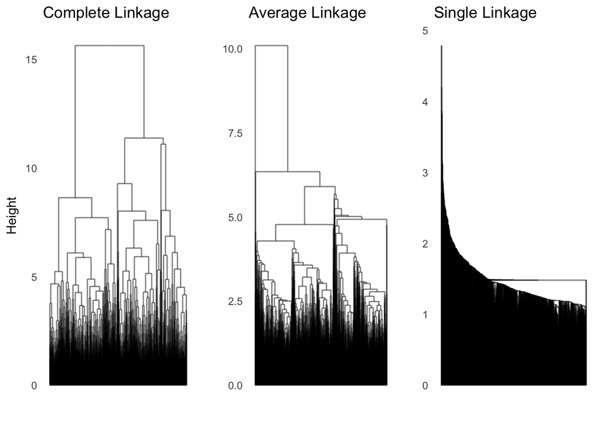

```r
dend.complete <- dendro_data(hc.complete, type = "rectangle")
plot.complete <- ggplot(segment(dend.complete)) +
  geom_segment(aes(x = x, y = y, xend = xend, yend = yend), alpha = 0.5) +
  labs(y = "Height", x = "", title = "Complete Linkage") + theme_minimal() +
  theme(axis.text.x = element_blank(), axis.ticks.x = element_blank(),
        panel.grid = element_blank())

dend.average <- dendro_data(hc.average, type = "rectangle")
plot.average <- ggplot(segment(dend.average)) +
  geom_segment(aes(x = x, y = y, xend = xend, yend = yend), alpha = 0.5) +
  labs(y = "", x = "", title = "Average Linkage") + theme_minimal() +
  theme(axis.text.x = element_blank(), axis.ticks.x = element_blank(),
        panel.grid = element_blank())

dend.single <- dendro_data(hc.single, type = "rectangle")
plot.single <- ggplot(segment(dend.single)) +
  geom_segment(aes(x = x, y = y, xend = xend, yend = yend), alpha = 0.5) +
  labs(y = "", x = "", title = "Single Linkage") + theme_minimal() +
  theme(axis.text.x = element_blank(), axis.ticks.x = element_blank(),
        panel.grid = element_blank())

grid.arrange(plot.complete, plot.average, plot.single, ncol = 3)
```

### Cut Trees at Different Heights

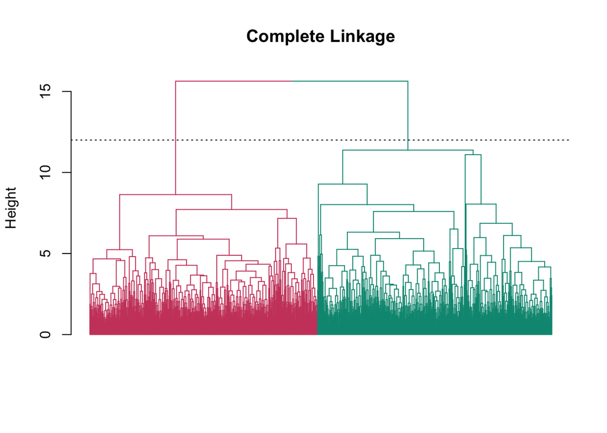

```r
dendro.complete <- as.dendrogram(hc.complete)

par(mfrow = c(1,1))

#cut tree at a height of 12 resulting in 2 clusters
dendro.complete %>%
  color_branches(k = 2) %>%
  plot(main = "Complete Linkage", ylab = "Height", leaflab = "none")
abline(h = 12, lty = 3)
```

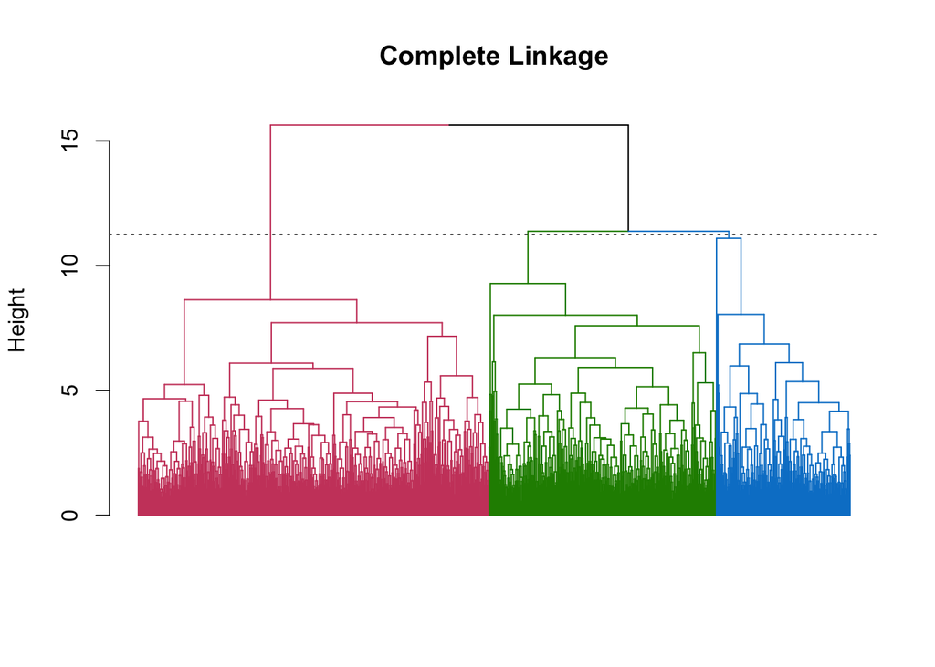

```r
#cut tree at a height of 11.25 resulting in 3 clusters
dendro.complete %>% color_branches(k = 3) %>%
    plot(main = "Complete Linkage", ylab = "Height", leaflab = "none")
  abline(h = 11.25, lty = 3)
```

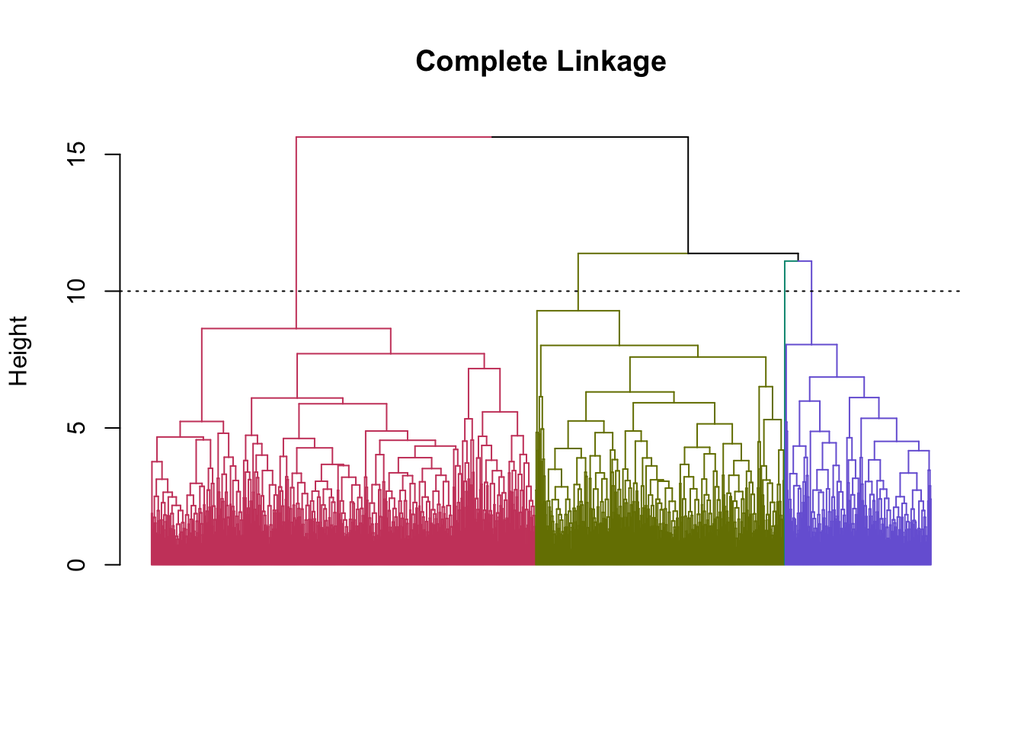

```r
#cut tree at a height of 10 resulting in 4 clusters
dendro.complete %>%
  color_branches(k = 4) %>%
  plot(main = "Complete Linkage", ylab = "Height", leaflab = "none")
abline(h = 10, lty = 3)
```

### Health Models

#### 3 Cluster Model

Combine clusters grouping with original data outcome and covariants for clusters = 3

```r
hc.clusters.3 = cutree(hc.complete, 3)
hc_health_3 <- as.tibble(cbind(pop, hc.clusters.3)) %>%
  mutate(hc.clusters.3 = as.factor(hc.clusters.3)) %>%
  mutate(hc.clusters.3 = fct_relevel(hc.clusters.3, ref = "3"))

table(hc_health_3$hc.clusters.3)
```

```
##
##   3   1   2
## 494 189 320
```

Put 3 clusters (categorical) into a linear regression w/ covariates to estimate association with LTL.

```r
health_model_hc3 <- lm(logtelomean ~ hc.clusters.3 +
     lbxwbcsi + lbxlypct + lbxmopct + lbxnepct + lbxeopct + lbxbapct + age_cent + age_sq +
     as.factor(bmi_cat3) + as.factor(edu_cat) + as.factor(race_cat) + male, data = hc_health_3)

summary(health_model_hc3)
```

```
##
## Call:
## lm(formula = logtelomean ~ hc.clusters.3 + lbxwbcsi + lbxlypct +
##     lbxmopct + lbxnepct + lbxeopct + lbxbapct + age_cent + age_sq +
##     as.factor(bmi_cat3) + as.factor(edu_cat) + as.factor(race_cat) +
##     male, data = hc_health_3)
##
## Residuals:
##      Min       1Q   Median       3Q      Max
## -0.53994 -0.13496 -0.00556  0.12992  0.73785
##
## Coefficients:
##                         Estimate  Std. Error t value            Pr(>|t|)
## (Intercept)           3.65481426  8.15235298   0.448              0.6540
## hc.clusters.31        0.05409136  0.02415787   2.239              0.0254
## hc.clusters.32        0.03353936  0.01810729   1.852              0.0643
## lbxwbcsi             -0.00530818  0.00355819  -1.492              0.1361
## lbxlypct             -0.03550703  0.08150291  -0.436              0.6632
## lbxmopct             -0.04045732  0.08152952  -0.496              0.6198
## lbxnepct             -0.03486346  0.08148210  -0.428              0.6688
## lbxeopct             -0.03465533  0.08152507  -0.425              0.6709
## lbxbapct             -0.01580028  0.08268974  -0.191              0.8485
## age_cent             -0.00640722  0.00060803 -10.538 <0.0000000000000002
## age_sq               -0.00001335  0.00002143  -0.623              0.5335
## as.factor(bmi_cat3)2 -0.00906025  0.01590131  -0.570              0.5690
## as.factor(bmi_cat3)3 -0.01891015  0.01681296  -1.125              0.2610
## as.factor(edu_cat)2   0.02056150  0.01845878   1.114              0.2656
## as.factor(edu_cat)3   0.03278984  0.01780733   1.841              0.0659
## as.factor(edu_cat)4   0.00992153  0.02069345   0.479              0.6317
## as.factor(race_cat)2 -0.03786411  0.02709417  -1.398              0.1626
## as.factor(race_cat)3  0.00638655  0.02812628   0.227              0.8204
## as.factor(race_cat)4 -0.03677972  0.02513838  -1.463              0.1438
## male                 -0.03323509  0.01353863  -2.455              0.0143
##
## (Intercept)
## hc.clusters.31       *
## hc.clusters.32       .
## lbxwbcsi
## lbxlypct
## lbxmopct
## lbxnepct
## lbxeopct
## lbxbapct
## age_cent             ***
## age_sq
## as.factor(bmi_cat3)2
## as.factor(bmi_cat3)3
## as.factor(edu_cat)2
## as.factor(edu_cat)3  .
## as.factor(edu_cat)4
## as.factor(race_cat)2
## as.factor(race_cat)3
## as.factor(race_cat)4
## male                 *
## ---
## Signif. codes:  0 '***' 0.001 '**' 0.01 '*' 0.05 '.' 0.1 ' ' 1
##
## Residual standard error: 0.2024 on 983 degrees of freedom
## Multiple R-squared:  0.2527, Adjusted R-squared:  0.2382
## F-statistic: 17.49 on 19 and 983 DF,  p-value: < 0.00000000000000022
```

```r
health_model_hc3 %>% broom::tidy() %>% mutate(
  estimate = round(estimate, 4),
  std.error = round(std.error, 4),
  statistic = round(statistic, 4),
  p.value = round(p.value, 4))
```

```
## # A tibble: 20 x 5
##    term                 estimate std.error statistic p.value
##    <chr>                   <dbl>     <dbl>     <dbl>   <dbl>
##  1 (Intercept)           3.65     8.15         0.448  0.654
##  2 hc.clusters.31        0.0541   0.0242       2.24   0.0254
##  3 hc.clusters.32        0.0335   0.0181       1.85   0.0643
##  4 lbxwbcsi             -0.00530  0.00360     -1.49   0.136
##  5 lbxlypct             -0.0355   0.0815      -0.436  0.663
##  6 lbxmopct             -0.0405   0.0815      -0.496  0.620
##  7 lbxnepct             -0.0349   0.0815      -0.428  0.669
##  8 lbxeopct             -0.0347   0.0815      -0.425  0.671
##  9 lbxbapct             -0.0158   0.0827      -0.191  0.848
## 10 age_cent             -0.00640  0.000600   -10.5    0.
## 11 age_sq                0.       0.          -0.623  0.534
## 12 as.factor(bmi_cat3)2 -0.00910  0.0159      -0.570  0.569
## 13 as.factor(bmi_cat3)3 -0.0189   0.0168      -1.12   0.261
## 14 as.factor(edu_cat)2   0.0206   0.0185       1.11   0.266
## 15 as.factor(edu_cat)3   0.0328   0.0178       1.84   0.0659
## 16 as.factor(edu_cat)4   0.00990  0.0207       0.480  0.632
## 17 as.factor(race_cat)2 -0.0379   0.0271      -1.40   0.163
## 18 as.factor(race_cat)3  0.00640  0.0281       0.227  0.820
## 19 as.factor(race_cat)4 -0.0368   0.0251      -1.46   0.144
## 20 male                 -0.0332   0.0135      -2.45   0.0143
```

```r
health_model_hc3 %>% broom::glance() %>% mutate(p.value = round(p.value, 5))
```

```
## # A tibble: 1 x 11
##   r.squared adj.r.squared sigma statistic p.value    df logLik   AIC   BIC
##       <dbl>         <dbl> <dbl>     <dbl>   <dbl> <int>  <dbl> <dbl> <dbl>
## 1     0.253         0.238 0.202      17.5      0.    20   189. -336. -233.
## # ... with 2 more variables: deviance <dbl>, df.residual <int>
```

```r
confint(health_model_hc3)
```

```
##                                2.5 %         97.5 %
## (Intercept)          -12.34320185649 19.65283038226
## hc.clusters.31         0.00668444295  0.10149828418
## hc.clusters.32        -0.00199403532  0.06907275068
## lbxwbcsi              -0.01229071172  0.00167434367
## lbxlypct              -0.19544672128  0.12443265812
## lbxmopct              -0.20044923136  0.11953459586
## lbxnepct              -0.19476232230  0.12503541015
## lbxeopct              -0.19463850288  0.12532784760
## lbxbapct              -0.17806899404  0.14646843317
## age_cent              -0.00760041156 -0.00521402197
## age_sq                -0.00005540554  0.00002870533
## as.factor(bmi_cat3)2  -0.04026467519  0.02214416786
## as.factor(bmi_cat3)3  -0.05190356450  0.01408326782
## as.factor(edu_cat)2   -0.01566163912  0.05678464648
## as.factor(edu_cat)3   -0.00215491646  0.06773458931
## as.factor(edu_cat)4   -0.03068688127  0.05052994365
## as.factor(race_cat)2  -0.09103318373  0.01530496131
## as.factor(race_cat)3  -0.04880791151  0.06158101697
## as.factor(race_cat)4  -0.08611077896  0.01255134270
## male                  -0.05980302983 -0.00666715642
```

```r
#summary table of betas and confidence intervals for the cluster variables.

hc3_betas_confint <- as.data.frame(c(health_model_hc3$coefficients["hc.clusters.31"], health_model_hc3$coefficients["hc.clusters.32"])) %>%
  rownames_to_column() %>%
  rename("variable" = 1) %>%
  rename("beta" = 2) %>%
  mutate('95%CI' = c("0.007, 0.101", "-0.002, 0.069"),
       'P-value' = c((summary(health_model_hc3)$coefficients[2,4]),
                      summary(health_model_hc3)$coefficients[3,4]))

hc3_betas_confint
```

```
##         variable       beta         95%CI    P-value
## 1 hc.clusters.31 0.05409136  0.007, 0.101 0.02537385
## 2 hc.clusters.32 0.03353936 -0.002, 0.069 0.06428858
```